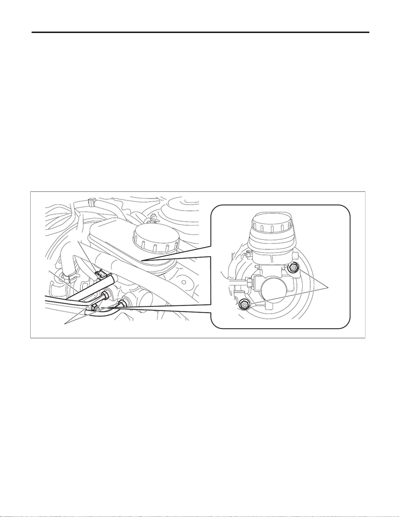

Master Cylinder

BRAKE

8. Master Cylinder

A: REMOVAL

CAUTION:

• Do not allow brake fluid to come in contact with the painted surface of the vehicle body. If it does,

wash off with water and wipe away completely.

• Prepare a container to catch grease or oil, etc. If any grease or oil spills, wipe it off and clean im-

mediately to prevent from penetrating into floor or flowing outside.

1) Disconnect the ground cable from battery. <Ref. to NT-5, BATTERY, NOTE, Note.>

NOTE:

For models other than STI model, disconnect the ground terminal from battery sensor.

2) Drain brake fluid from the reservoir tank completely.

3) Remove the master cylinder assembly.

(1) Disconnect the fluid level gauge connector (a).

(2) Disconnect the clutch hose (b). (MT model)

(3) Disconnect the brake pipe (c).

(4) Remove the nut (d), and slowly remove the master cylinder assembly from the vacuum booster as-

sembly.

BR-00912

(d)

(c)

(a)

(b)

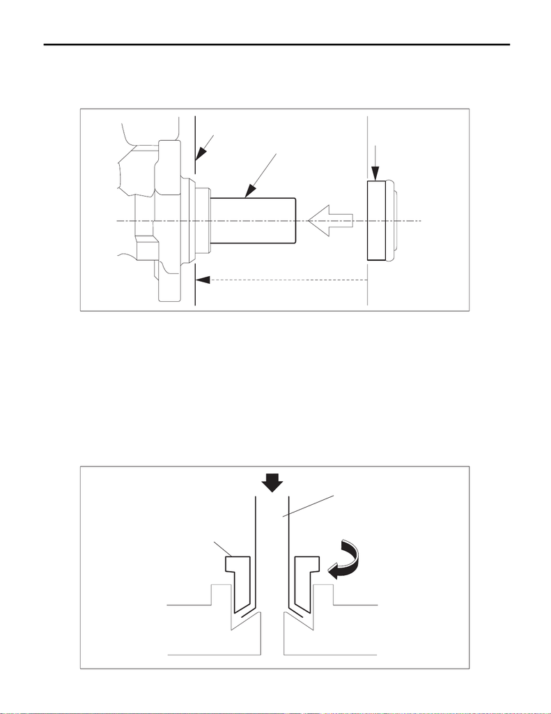

Master Cylinder

BRAKE

B: INSTALLATION

1) Replace the seal sub assembly for the master cylinder assembly with a new part.

CAUTION:

Be careful not to install the seal sub assembly in the wrong location.

2) Install the master cylinder assembly.

Tightening torque:

13 N·m (1.3 kgf-m, 9.6 ft-lb)

3) Turn and tighten the flare nut (b) by hand while pressing the brake pipe (a) toward the master cylinder as-

sembly side.

CAUTION:

Be careful not to make scratches or other damage to the inside surface of the brake pipe flare.

Tightening torque:

19 N·m (1.9 kgf-m, 14.0 ft-lb)

(a) Primary piston (b) Seal sub ASSY (c) Install the seal sub ASSY to this

surface.

(c)

(a)

(b)

BR-00948

BR-01088

(a)

(b)

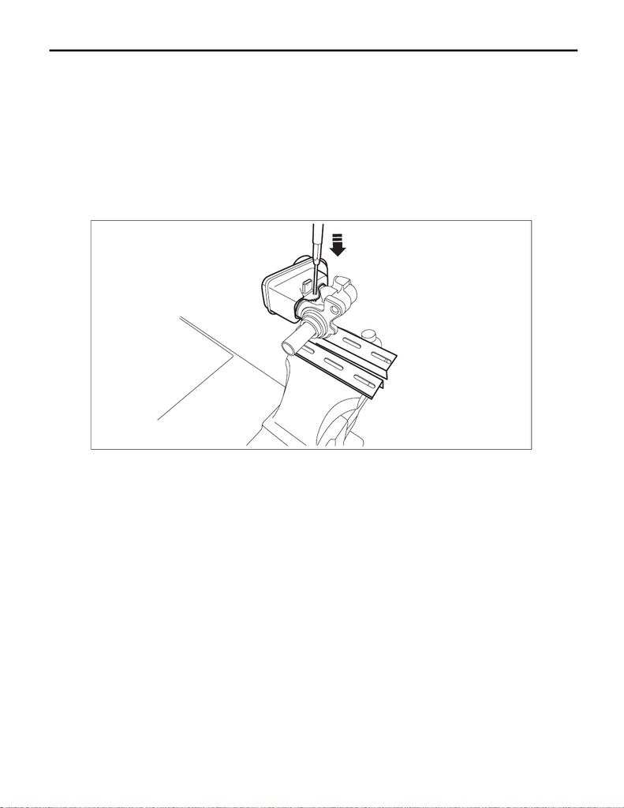

Master Cylinder

BRAKE

4) Bleed air from the brake system and clutch system (MT model). <Ref. to BR-65, PROCEDURE, Air Bleed-

ing.>

5) Connect the battery ground terminal. <Ref. to NT-5, BATTERY, NOTE, Note.>

NOTE:

For models other than STI model, connect the ground terminal to battery sensor.

C: DISASSEMBLY

1) Remove the reservoir tank.

CAUTION:

Be careful not to tighten a vise excessively.

(1) Place the master cylinder assembly between aluminum plates and fix it on a vise.

(2) Drive out the pin using a punch and a hammer to remove the reservoir tank.

2) Remove the seal from the cylinder body assembly.

D: ASSEMBLY

1) Install the seal to the cylinder body assembly.

2) Install the reservoir tank.

CAUTION:

Be careful not to tighten a vise excessively.

(1) Place the master cylinder assembly between aluminum plates and fix it on a vise.

(2) Drive the pin using a punch and a hammer to install the reservoir tank.

BR-01289